# CibNav : Analyse exploratoire des données

Authors

Quentin Loridant

Pierre Camilleri

Published

April 18, 2023

## Préparation des données

Les données explorées sont celles de l’échantillon d’entraînement.

```r
df <- tbl(con, "dataset_train") %>%
  collect()
```

```r
df$cible <- as.logical(df$cible)
df$annee_visite <- as.integer(df$annee_visite)
df$id_gin_visite <- as.integer(df$id_gin_visite)
df$sitrep_history <- as.integer(df$sitrep_history)

df$idc_gin_categ_navigation <- fct_recode(
  as.factor(df$idc_gin_categ_navigation),
  "5ème (eaux abritées)"="1",
  "4ème (5 milles des eaux abritées)"="2",
  "4ème (5 milles des eaux abritées)"="3",
  "4ème (5 milles des eaux abritées)"="4",
  "3ème (20 milles de la terre)"="5",
  "3ème (20 milles de la terre)"="7",
  "2ème (200 milles d'un port)"="8",
  "2ème (200 milles d'un port)"="9",
  "1ère"="10",
  "6ème plaisance (2 milles d'un abri)"="11",
  "5ème plaisance (5 milles d'un abri)"="12",
  "4ème plaisance (20 milles d'un abri)"="13",
  "3ème plaisance (60 milles d'un abri)"="14",
)

# fonction qui permet de ne garder qu'une observation par navire
to_nav <- function(df) {
  donnees_navire <- c(
    "id_nav_flotteur",
    "num_version",
    "genre_navigation",
    "materiau_coque",
    "situation_flotteur",
    "type_carburant",
    "type_moteur",
    "longueur_hors_tout",
    "log_longueur_hors_tout",
    "jauge_oslo",
    "log_jauge_oslo",
    "puissance_administrative",
    "log_puissance_administrative",
    "age",
    "longueur_lte12",
    "longueur_e12",
    "longueur_mt12",
    "idc_gin_categ_navigation"
  )

  df_nav <- df %>%
    group_by(id_nav_flotteur) %>%
    filter(date_visite == max(date_visite)) %>%
    ungroup() %>%
    select(any_of(donnees_navire))

  return(df_nav)
}
```

Les catégories de navigation restreintes sont regroupées avec les non-restreintes.

## Explorations automatiques préliminaires

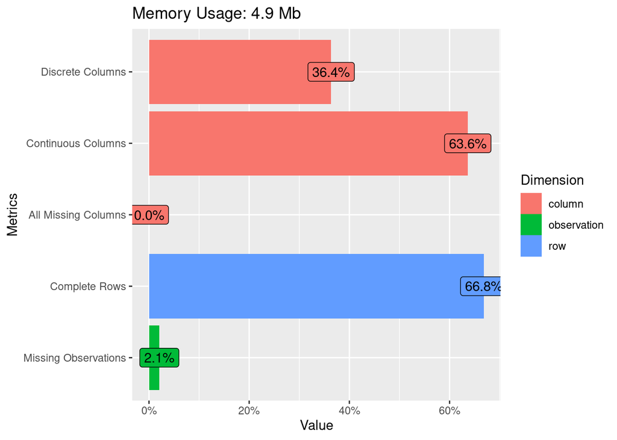

```r
df_no_log <- df %>% select(!starts_with("log"))
plot_intro(df_no_log)
```

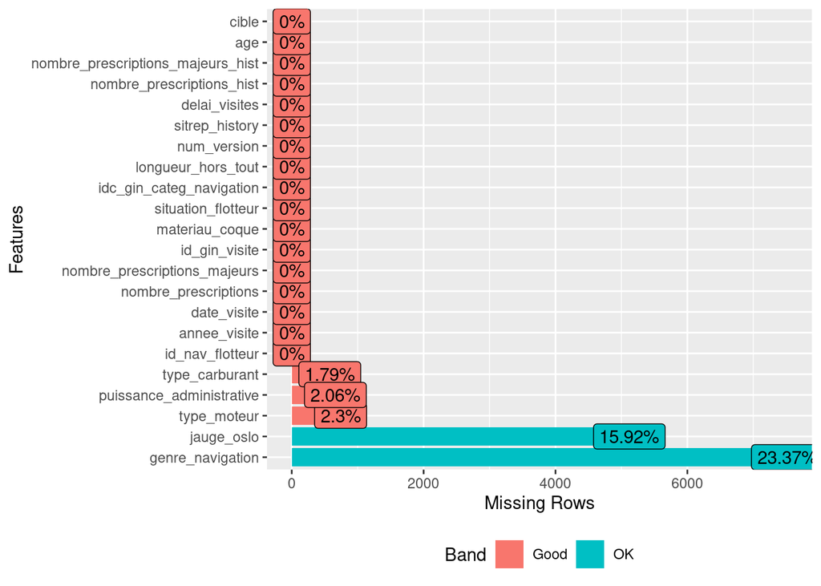

```r
plot_missing(df_no_log)
```

Valeurs manquantes essentiellement pour :

- le genre de navigation
- la jauge oslo

Quelques valeurs manquantes pour :

- les informations moteur (nbre, type, carburant)
- la puissance admininistrative

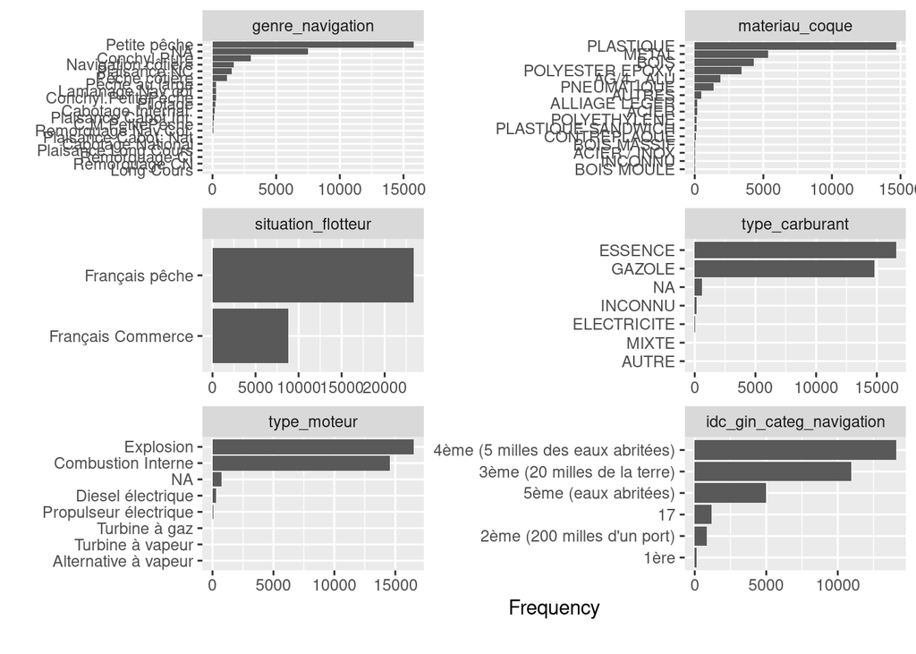

Histogrammes des variables catégorielles

```r
exclude <- c(
  "date_visite",
  "cible"
  )
plot_bar(df %>% select(!any_of(exclude)), ncol = 2L)
```

Observations :

### `genre_navigation`

- Valeurs multiples agrégées : exemple “Conchyl.Petite Pêche”
- Pourrait être regroupé en catégories plus générales, par ex : “Cabotage International” + “Cabotage national” < “Cabotage”

### `materiau_coque`

- Divers niveau de précision, par exemple “BOIS” vs “BOIS MASSIF”, “BOIS MOULE” ou “CONTREPLAQUE”
- Valeurs manquantes avec modalité “INCONNU”
- Queue de modalités avec peu d’observations. À regrouper avec “AUTRES”

### `type_carburant`

- Présence de `NA` ET “INCONNU”
- Queue de modalités avec peu d’observations. À regrouper avec “AUTRES”

### `type_moteur`

- Queue de modalités avec peu d’observations. À regrouper dans une catégorie “AUTRES”

```r
df <- df %>%
  mutate(
    genre_navigation = fct_lump_min(
      genre_navigation,
      min = 500,
      other_level = "Autre"
    ),

    materiau_coque = fct_recode(
      materiau_coque,
      METAL = "AG/4 - ALU",
      METAL = "ACIER",
      METAL = "ACIER / INOX",
      METAL = "ALLIAGE LEGER",
      BOIS = "BOIS MASSIF",
      BOIS = "BOIS MOULE",
      BOIS = "CONTREPLAQUE",
      PLASTIQUE = "POLYESTER EPOXY",
      PLASTIQUE = "POLYETHYLENE",
      PLASTIQUE = "PLASTIQUE SANDWICH",
      NULL = "INCONNU"
    ),

    type_carburant = fct_lump_min(
      type_carburant,
      min = 500,
      other_level = "Autre"
    ),

    type_moteur = fct_lump_min(
      type_moteur,
      min = 500,
      other_level = "Autre"
      ),
  )
```

Les catégories avec peu de modalités ont été regroupées dans une catégorie “Autre”.

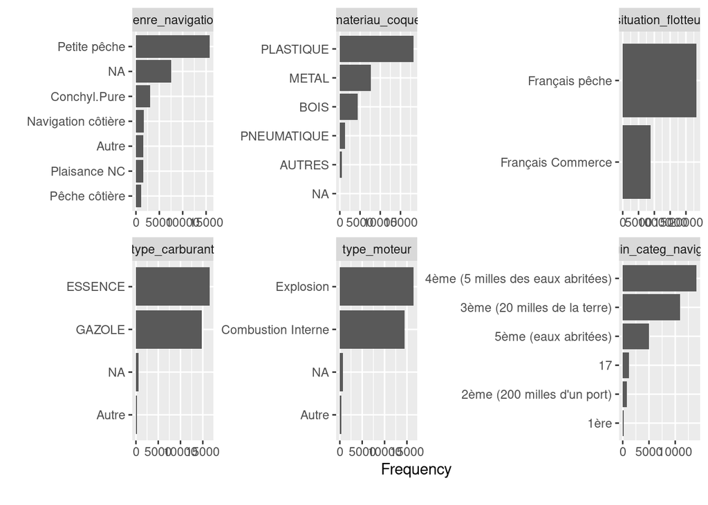

Histogrammes des variables catégorielles après regroupements de modalités

```r
plot_bar(df %>% select(!any_of(exclude)))
```

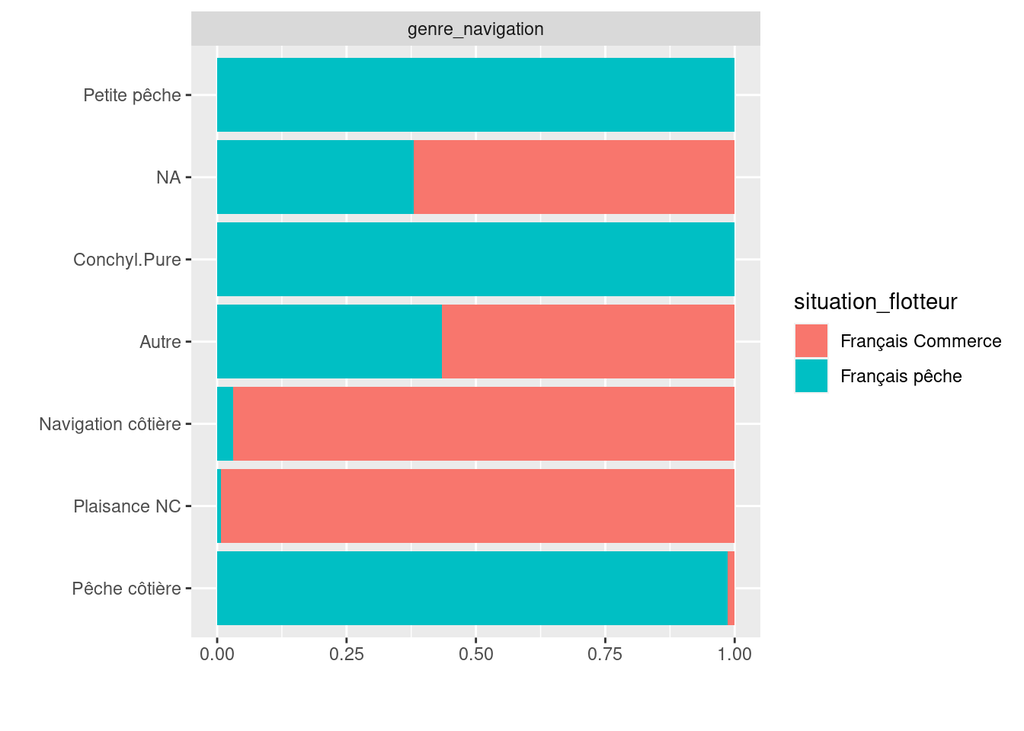

Vérification correspondance genre <> situation flotteur

```r
plot_bar(to_nav(df) %>% select(genre_navigation, situation_flotteur), by = "situation_flotteur")
```

À quelques rares exceptions près, la correspondance `genre_navigation` <> `situation_flotteur` est assez cohérente.

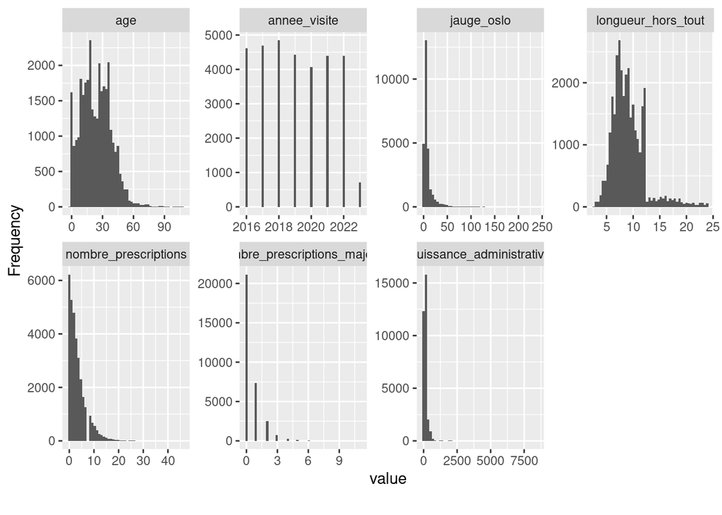

Histogrammes des variables continues

```r
include = c(
  "age",
  "annee_visite",
  "jauge_oslo",
  "longueur_hors_tout",
  "nombre_prescriptions",
  "nombre_prescriptions_majeurs",
  "puissance_administrative"
  )
plot_histogram(
  df %>% select(any_of(include)),
  geom_histogram_args = list(bins = 50L)
)
```

Observations :

- `age` : Distribitution bi-modale avec un mode ~ 15 ans et un pic ~30 ans. Des pics ponctuels s’ajoutent à cette distribution : peut-être des arrondis ?
- `annee_visite` : quasi-uniforme sur 2016 2022 puis très peu d’obs en 2023.
- `jauge_oslo`, `puissance_administrative` - présence de valeurs extrêmes et distribution asymétrique, `longueur_hors_tout` distribution asymétrique. Appliquer une transformation log permet une meilleure analyse des données.
- `longueur_hors_tout` : effet de seuil assez net à 12m.

```r
df <- df %>%
  mutate(
   jauge_oslo = ifelse(jauge_oslo == 0, 1, jauge_oslo),
   puissance_administrative = ifelse(puissance_administrative == 0, 1,
                                     puissance_administrative)
   )
df$log_jauge_oslo <- log10(df$jauge_oslo)
df$log_puissance_administrative <- log10(df$puissance_administrative)
df$log_longueur_hors_tout <- log10(df$longueur_hors_tout)

df$longueur_lte12 <- (df$longueur_hors_tout <= 12)
df$longueur_e12 <- (df$longueur_hors_tout > 11.99 & df$longueur_hors_tout < 12.01)
df$longueur_mt12 <- (df$longueur_hors_tout > 12)
```

On opère les transformations suivantes :

- passage des variables jauge oslo, puissance_administrative et longueur_hors_tout au logarithme.
- ajout de variables booléennes “longueur_lte12”, “longueur_e12”, “longueur_mt12” pour les longueures inférieures ou égales, strictement égales ou supérieurs au seuil de 12 mètres.

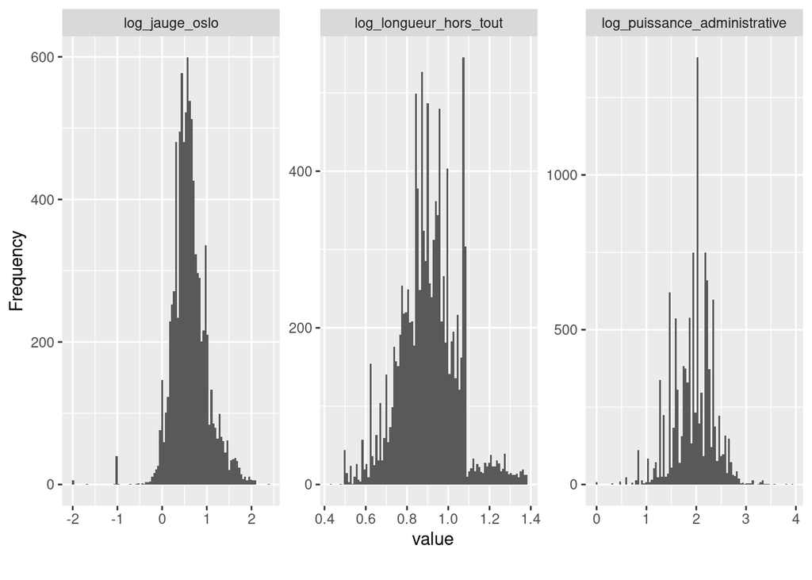

Histogrammes des variables continues log-transformées

```r
plot_histogram(
  to_nav(df) %>% select(log_jauge_oslo, log_puissance_administrative, log_longueur_hors_tout),
  geom_histogram_args = list(bins = 100L)
)
```

Après transformation, les distributions ont des distributions à peu près symétriques (modulo l’effet de seuil).

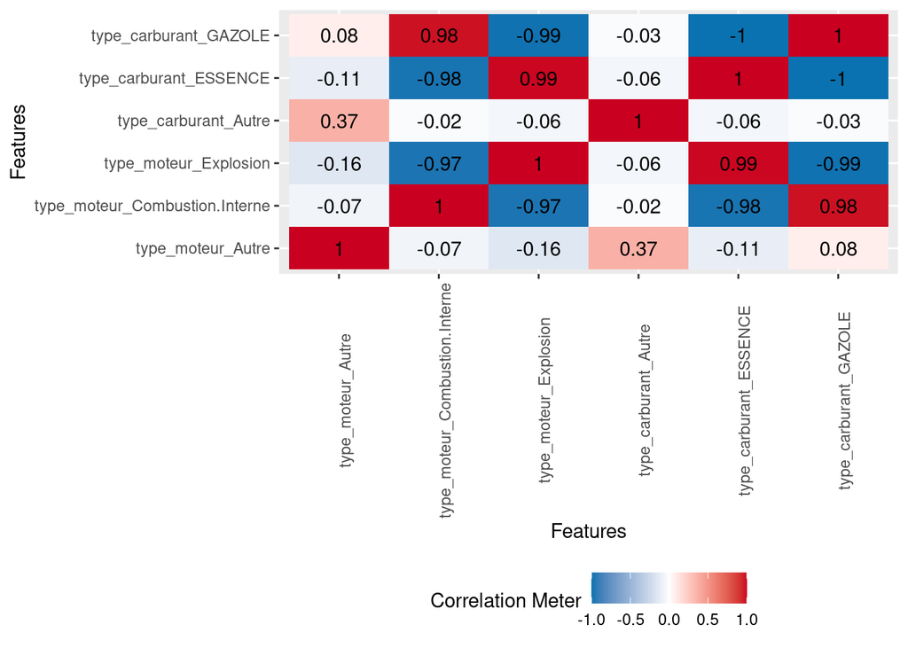

Corrélation entre variables type_moteur et type_carburant

```r
include <- c(
      "type_moteur",
      "type_carburant"
      )
plot_correlation(na.omit(to_nav(df) %>% select(any_of(include)), maxcat = 5L))
```

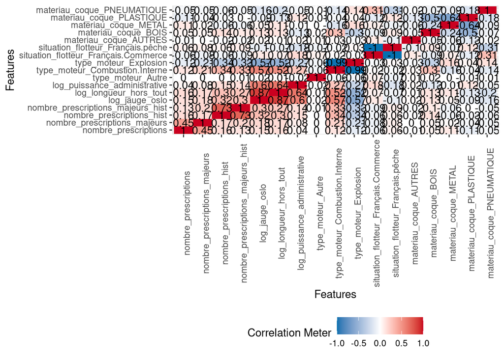

Corrélation entre variables

```r
include <- c(
      "nombre_prescriptions",
      "nombre_prescriptions_majeurs",
      "nombre_prescriptions_hist",
      "nombre_prescriptions_majeurs_hist",
      "type_moteur",
      "situation_flotteur",
      "log_jauge_oslo",
      "log_longueur_hors_tout",
      "log_puissance_administrative",
      "materiau_coque"
      )
plot_correlation(na.omit(df %>% select(any_of(include)), maxcat = 5L))
```

Sans surprise, on retrouve les corrélations suivantes :

- Le type de moteur et le type carburant sont assez redondants :
  - explosion <> essence (Il s’agit de plutôt petits navires, avec moins de prescriptions)
  - combustion <> gazole
  - moteur éléctrique <> électricité
- Forte corrélation entre presc majeurs et mineures (idem pour prescriptions historiques)
- puissance administrative, longueur, jauge_oslo très correlés

Plus surprenant :

- Corrélation à investiguer entre nombre prescriptions et annee visite.

## Lien entre prescriptions mineures et majeures

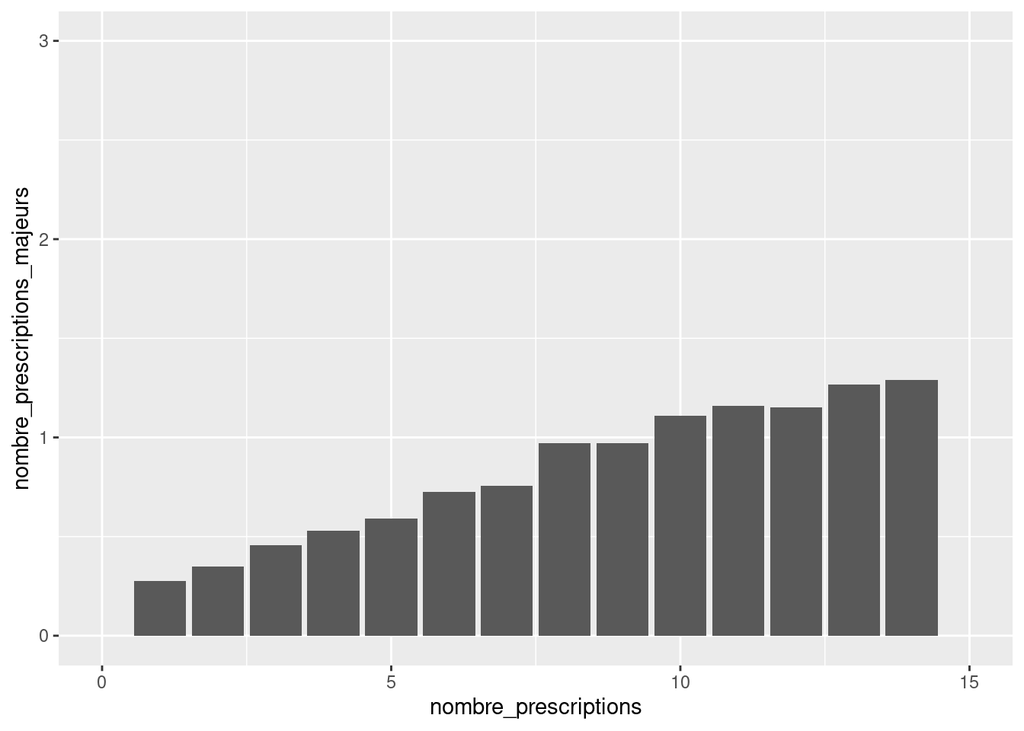

Nombre moyen de prescriptions majeures on fonction du nombre de prescriptions mineures

```r
ggplot(
  df %>% sample_n(10000),
  aes(x = nombre_prescriptions, y = nombre_prescriptions_majeurs),
) +
   stat_summary(fun = mean, geom = "col") +
   xlim(0, 15) +
   ylim(0, 3)
```

En moyenne, on trouve environ une prescription majeure pour 10 presciptions mineures. La relation entre les deux est (quasi-)linéaire.

## Lien entre prescriptions et année de visite

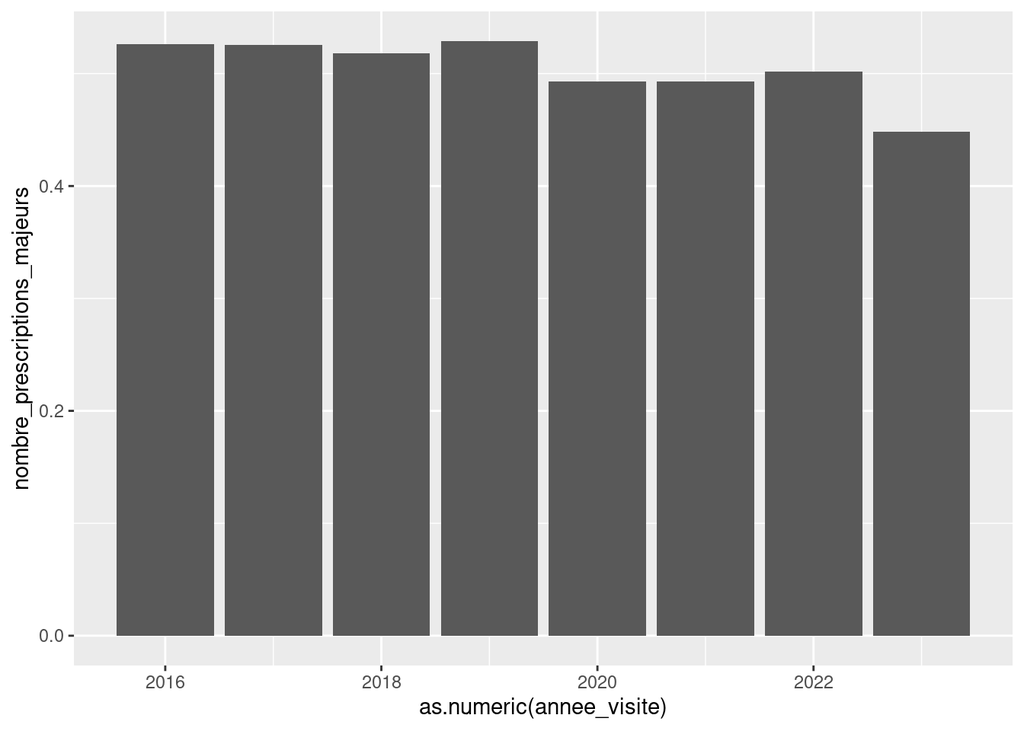

Lien entre nombre de prescriptions et année

```r
ggplot(
  df %>% sample_n(10000),
  aes(x = as.numeric(annee_visite), y = nombre_prescriptions_majeurs),
) +
   stat_summary(fun = mean, geom = "col")
```

L’année 2023 semble être légèrement en dessous de la tendance précédente, cependant le nombre d’observations est également plus faible que les autres, entraînant de fait une plus grande variabilité de l’estimation de la moyenne.

En tout état de cause, ces variations ne nous laissent pas penser qu’il y a une anomalie ou un changement de régime sur la durée d’observation.

## Distribution de l’âge

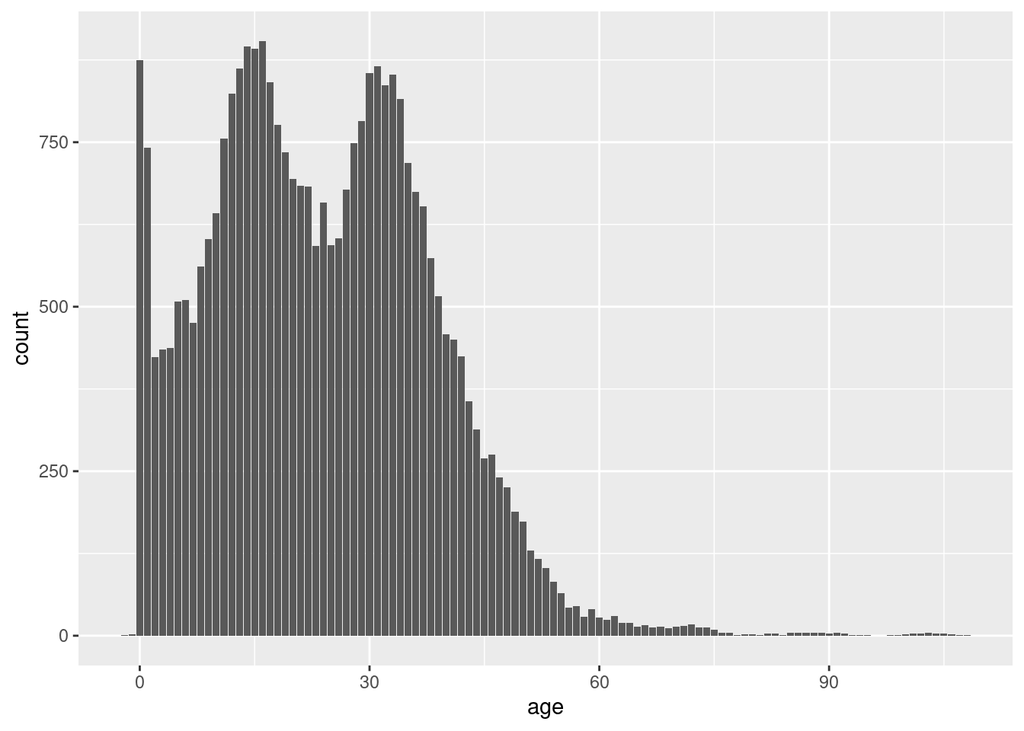

```r
ggplot(df, aes(x =age)) +
  geom_bar()
```

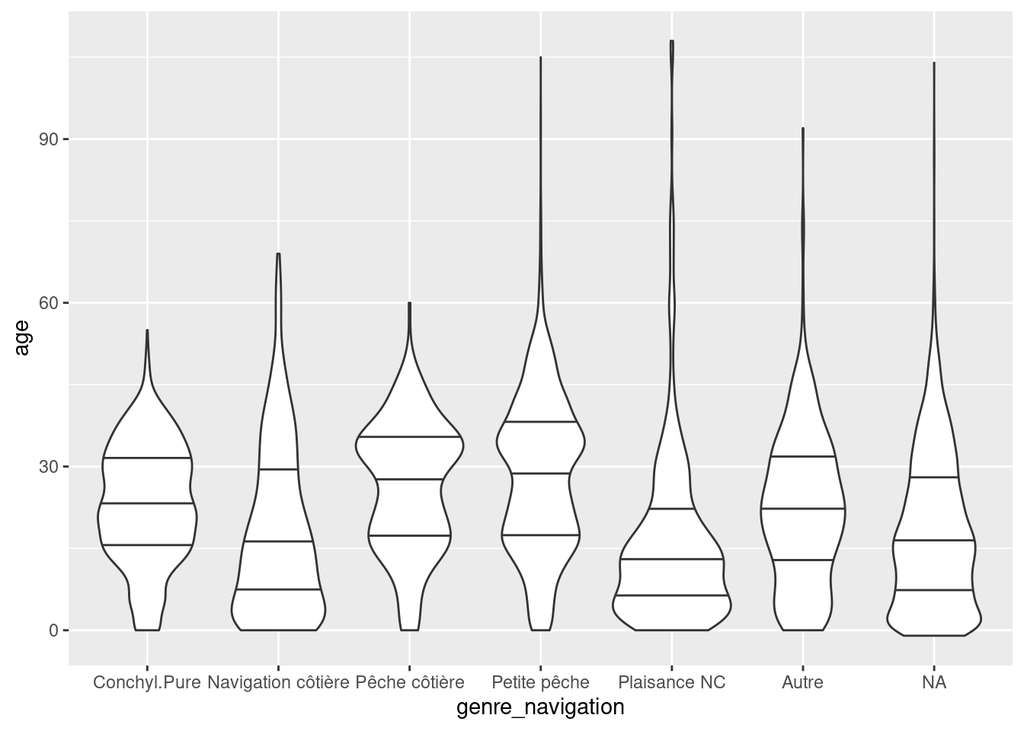

Distribution de l’âge en fonction du genre de navigation

```r
ggplot(to_nav(df),
       aes(x =genre_navigation, y=age)) +
  geom_violin(draw_quantiles = c(0.25, 0.5, 0.75))
```

La bi-modalité, surprenante, de l’âge est visible notamment pour les navires de pêche (petite pêche, conchyl, pêche côtière).

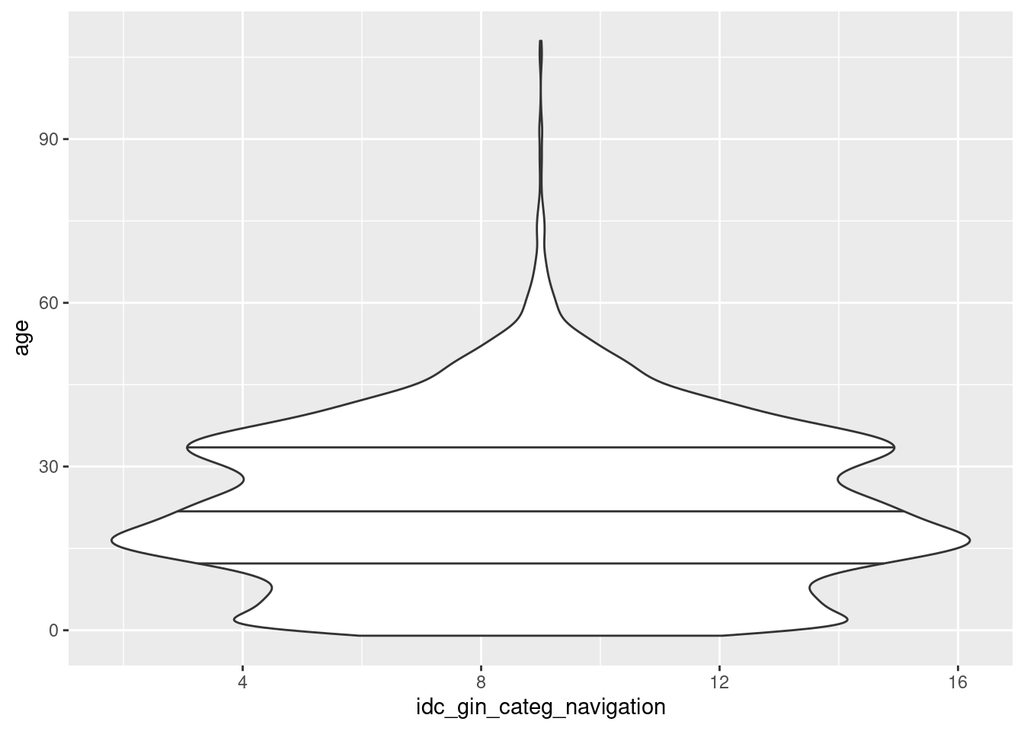

Distribution de l’âge en fonction de la catégorie de navigation

```r
ggplot(to_nav(df),
       aes(x = idc_gin_categ_navigation, y=age)) +
  geom_violin(draw_quantiles = c(0.25, 0.5, 0.75))
```

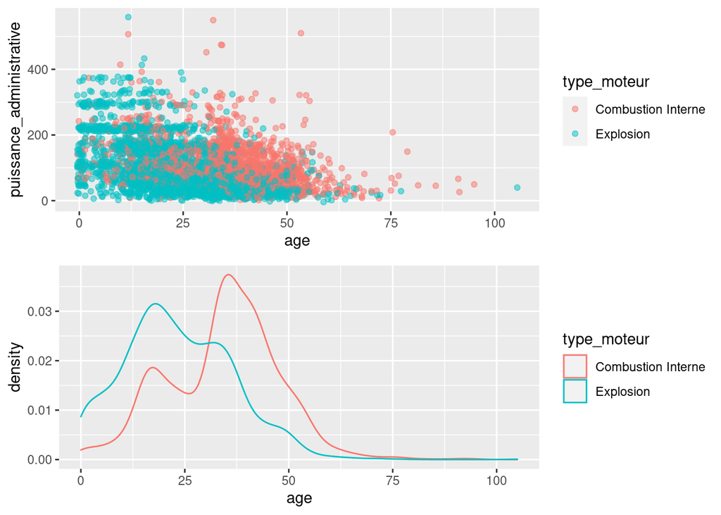

```r
df_pp <- to_nav(df) %>%
  filter(
    genre_navigation %in% c("Petite pêche"),
    type_moteur %in% c("Explosion", "Combustion Interne")
  )

p1 <- ggplot(df_pp,
       aes(x = age, y = puissance_administrative, color = type_moteur)) +
                 geom_jitter(height = 10, width = 0.5, alpha = 0.5)

p2 <- ggplot(df_pp,
       aes(x = age, color = type_moteur)) +
                 geom_density()

bayesplot_grid(p1, p2)
```

Chacun des modes de la distribution est associé à un type de moteur ! Y a-t-il eu un changement législatif ?

## Relation entre longueur et puissance

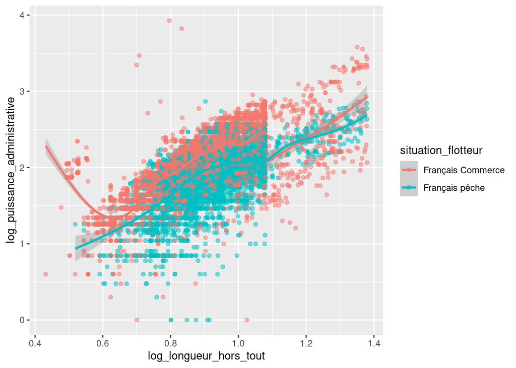

Puissance par rapport à la longueur du navire

```r
ggplot(
   to_nav(df),
   aes(
     x = log_longueur_hors_tout,
     y = log_puissance_administrative,
     color =situation_flotteur
   )
 ) +
   geom_point(alpha = 0.5) +
   geom_smooth(
     aes(color = situation_flotteur, group =interaction(situation_flotteur, longueur_mt12)),
     method="gam"
   )
```

Ici on remarque plusieures choses intéressantes :

- Pour les navires commerciaux, il y a deux dynamiques puissance <> longueur très différentes (deux groupes de points rouges qui forment des droites parallèles), bien visibles pour les grandes longueurs.
- Il y a un effet de seuil important à la limite règlementaire pour les navires commerciaux.
- Il y a également un certain nombre de valeurs extrêmes de puissance pour des valeurs de longueur ~5m (log_long ~0.8)
- Enfin, il y a un cluster de valeurs atypiques pour de faibles longueurs.
- Pour les navires de pêches, il semble y avoir plus d’homogénéité, avec une relation quasi linéaire (rappel : en log-log)

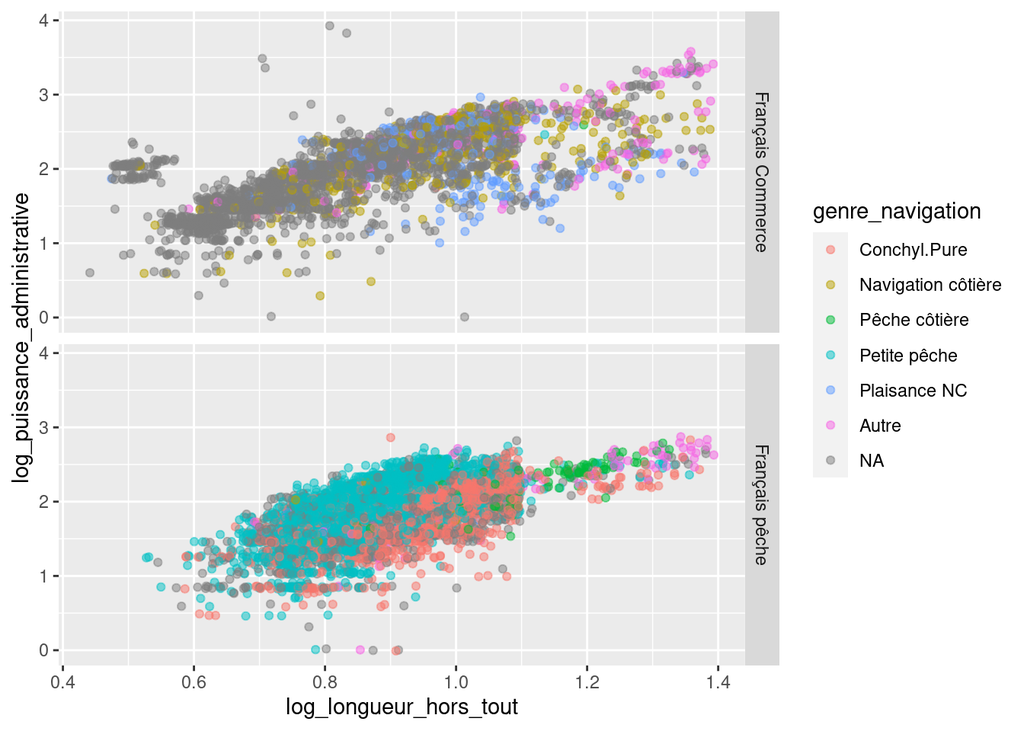

Puissance par rapport à la longueur du navire par genre

```r
ggplot(
   to_nav(df),
   aes(x = log_longueur_hors_tout, y = log_puissance_administrative, color =genre_navigation),
   ) +
    geom_point(
      position = position_jitter(width= 0.02, height =0.02),
      alpha = 0.5
    ) +
    facet_grid(rows = vars(situation_flotteur))
```

Avec cette visualisation, on voit même 3 dynamiques :

- la dynamique du bas représente plutôt des navires de plaisance
- La navigation côtière s’insère entre les deux
- La dynamique du haut sont des navires étiquetés “Autre”, il s’agit de navires de remorquage et de pilotage avec des puissances supérieures.
- Les navires de cabotage international sont partagés entre les deux

Concernant le cluster de petits navires :

- Genre essentiellement inconnu, sauf 2 > Navigation côtière & plaisance. Hypothèse : petits hors bord de navig côtière

Concernant les navires de pêche :

- Conchyl semble moins puissants en moyenne que petite pêche
- Ce qui semble différencier la petite pêche de la pêche côtière semble être la taille du navire.

Autres observations :

- Étonnement, il semble y avoir deux dynamiques pour les navires de plaisance également de longueur hors tout infra seuil

  Hypothèse : deux types de motorisations différentes

## Relation entre puissance et motorisation

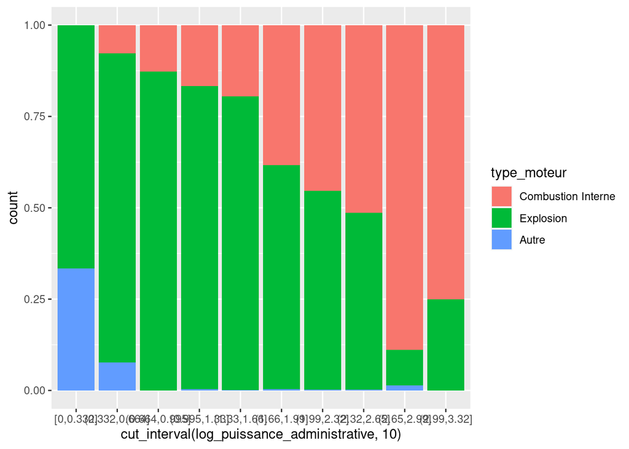

Distribution de motorisation en fonction de la puissance

```r
ggplot(
   na.omit(to_nav(df)),
   aes(x = cut_interval(log_puissance_administrative, 10), fill = type_moteur)
   ) +
   geom_bar(position = position_fill())
```

On observe :

- Plus le navire est puissant, plus il aura tendance à utiliser un moteur à combustion interne.

## Relation entre longueur et jauge oslo

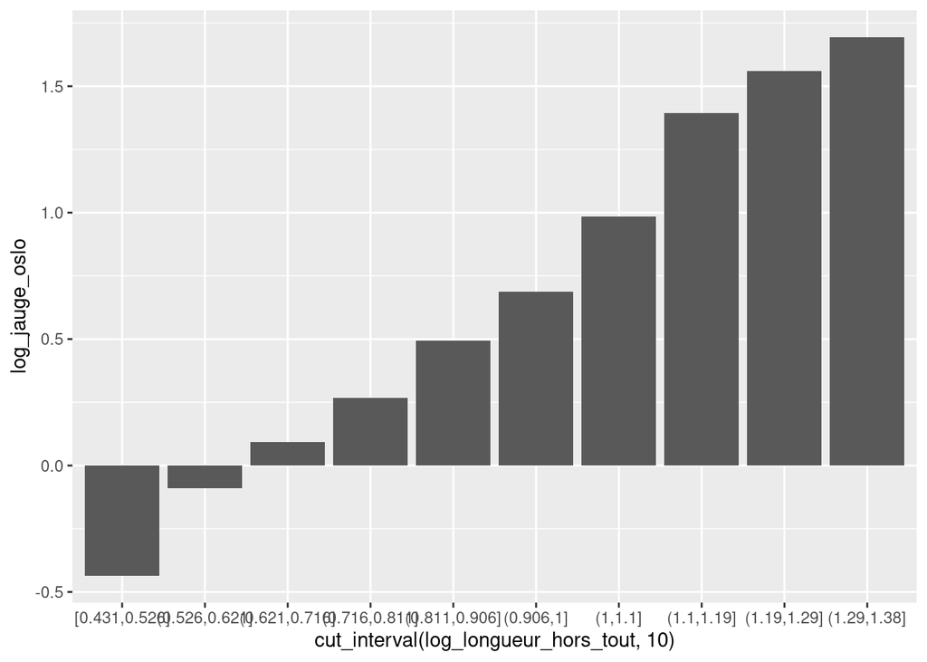

Jauge oslo moyenne en fonction de la longueur

```r
ggplot(
    to_nav(df),
    aes(x = cut_interval(log_longueur_hors_tout, 10), y = log_jauge_oslo)
    ) +
    stat_summary(fun = mean, geom = "bar")
```

Lien très net entre longueur hors tout et jauge oslo (en log-log).

## Exploration du nombre de prescriptions majeures

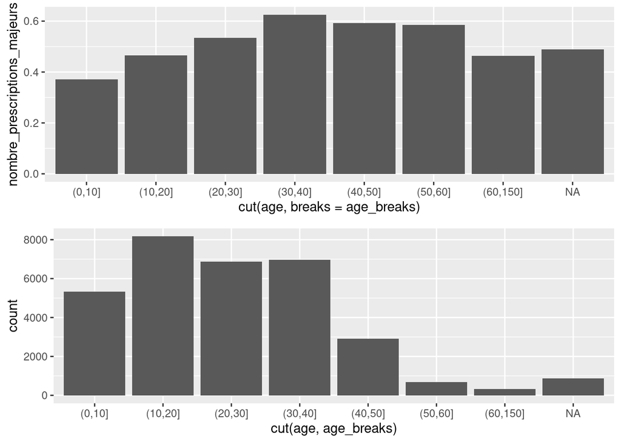

Nombre moyen de prescriptions majeures en founction de l’âge (et distribution des navires par âge)

```r
age_breaks <- c(0, 10, 20, 30, 40, 50, 60, 150)
p1 <- ggplot(
       df,
       aes(
         x = cut(age, breaks = age_breaks),
         y = nombre_prescriptions_majeurs
       )) +
  stat_summary(fun = "mean", geom = "col")

p2 <- ggplot(
  df,
  aes(
      x = cut(age, age_breaks)
      )) +
  geom_bar()

bayesplot_grid(p1, p2)
```

Variations non monotones des prescriptions majeures avec l’âge :

- Phase croissante entre 0 et 40 ans (nette majorité des navires)
- Puis phase légèrement décroissante à partir de là.

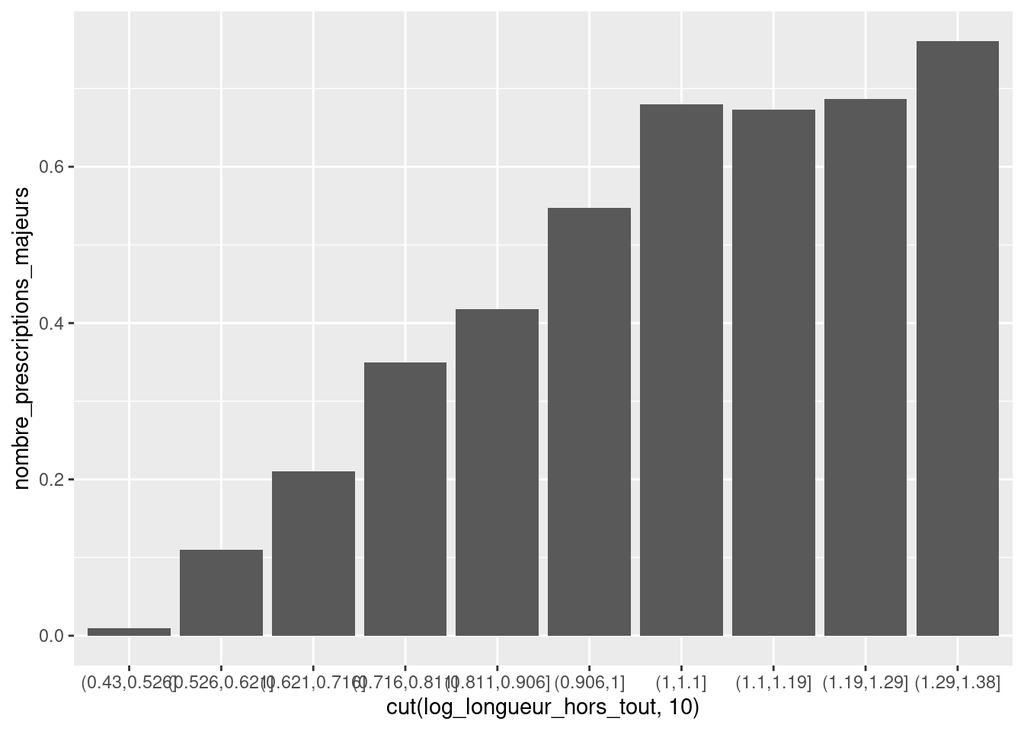

Nombre moyen de prescriptions majeures par longueur

```r
ggplot(
       df,
       aes(
         x = cut(log_longueur_hors_tout, 10),
         y = nombre_prescriptions_majeurs
       )) +
  stat_summary(fun = "mean", geom = "col")
```

Variations quasi linéaire des prescr maj avec le log de la log_longueur_hors_tout.

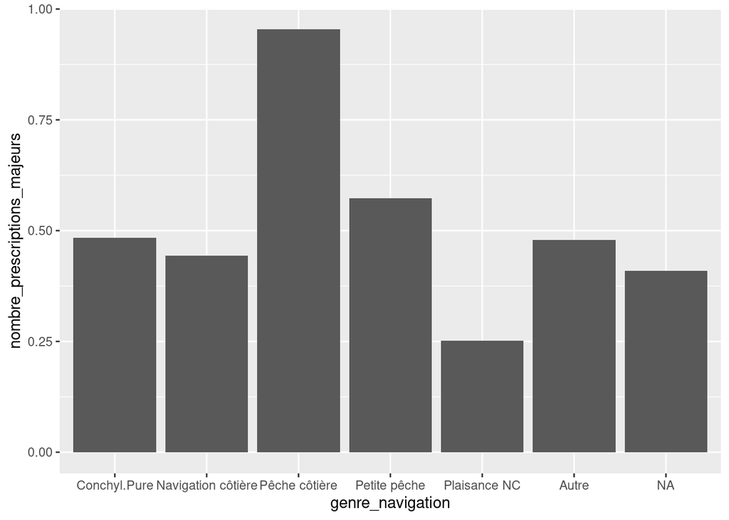

Nombre moyen de prescriptions majeures par genre de navigation

```r
ggplot(
       df,
       aes(
         x = genre_navigation,
         y = nombre_prescriptions_majeurs
       )) +
  stat_summary(fun = "mean", geom = "col")
```

Les activités de pêche semblent avoir plus de prescriptions majeures. Les activités de plaisance en ont le moins. À noter que la pêche côtière a aussi les plus grands navires, et nous avons vu que cela entraîne un plus grand nombre de prescriptions.

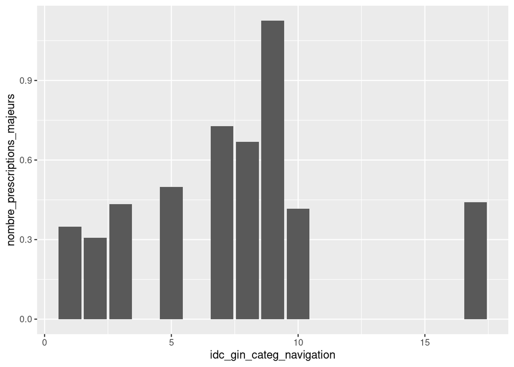

Nombre moyen de prescriptions majeures par categorie de navigation

```r
ggplot(
       df,
       aes(
         x = idc_gin_categ_navigation,
         y = nombre_prescriptions_majeurs
       )) +
  stat_summary(fun = "mean", geom = "col")
```

Le nombre de prescriptions majeures augmente nettement avec la catégorie de navigation : plus elle est permissive, plus le nombre de prescriptions est important.

Une exception notable : la 1ère catégorie de navigation a relativement peu de prescriptions majeures. On peut faire le lien avec l’âge de la flotte beaucoup plus jeune constatée pour cette catégorie.